# Latent space models

Pablo Barbera

October 31, 2017

#### Estimating political ideology

In this guided coding session, we will apply a latent space model to the network of users following 10 or more political accounts in the US. We will explore whether we can use this method to derive valid estimates of political ideology. This exercise is based on our paper published in [Psychological Science](http://pss.sagepub.com/content/26/10/1531).

The first is to load the matrix of users following political accounts. If you want to see how the data was collected, as well as the code to create it, you can go [here](https://github.com/pablobarbera/twitter_ideology/tree/master/2016-election). We will load the `Matrix` package to deal with this sparse matrix, and `tweetscores` to estimate correspondence analysis.

```r
library(Matrix)
#devtools::install_github("pablobarbera/twitter_ideology/pkg/tweetscores")
library(tweetscores)
# adjacency matrix
load("../data/US-follower-network.rdata")
dim(y)
```

```
## [1] 168620    585
```

```r
y[1:5,1:5]
```

```
## 5 x 5 sparse Matrix of class "ngCMatrix"
##            ABC ACLU AEI ajam algore
## 387756785    |    .   .    .      |
## 32487224     |    .   .    |      |
## 178006237    |    .   .    .      .
## 328863802    |    .   .    .      .
## 1258024164   |    .   |    .      .
```

```r
# data about columns
users <- read.csv("../data/accounts-twitter-data.csv")
head(users)
```

```
##         twitter     id_str   screen_name       twitter_name
## 1           abc   28785486           ABC           ABC News
## 2          aclu   13393052          ACLU      ACLU National
## 3           aei   30864583           AEI                AEI
## 4          ajam 1178700896          ajam Al Jazeera America
## 5        algore   17220934        algore            Al Gore
## 6 andercrenshaw   20209807 AnderCrenshaw     Ander Crenshaw
##                                                                                                                                                      description
## 1                                                                             See the whole picture with @ABC News. Join us on Facebook: https://t.co/ewMNZ54axm
## 2                  The ACLU is a nonprofit, nonpartisan, legal and advocacy organization devoted to protecting the basic civil liberties of everyone in America.
## 3 Cherish freedom? The power of enterprise? Opportunity for all? It's these core beliefs that drive the scholars and staff at the American Enterprise Institute.
## 4                                             Reporting unbiased, fact-based and in-depth journalism that gets you closer to the people at the heart of the news
## 5
## 6                                                                                                                                      Member of Congress, FL-04
##   followers_count statuses_count friends_count
```

[output cut: 27 more lines]

```r
table(users$type)
```

```
##
##          Congress   Interest groups       Journalists     Media Outlets
##               516                10                10                33
## Other Politicians Primary Candidate
##                15                 7
```

One of the advantages of correspondence analysis with respect to other methods is that we can add “supplementary columns” – parts of the matrix not included in the estimation of the latent space, but that can be then projected onto that same latent space. We will take advantage of this to make sure we only train the latent space model with Members of Congress; then we will add the other accounts.

```r
# choosing supplementary columns
included <- users$twitter[users$type %in% c("Congress")]
supcol <- which(tolower(colnames(y)) %in% included == FALSE)
colnames(y)[supcol] ## these will be excluded
```

```
##  [1] "ABC"             "ACLU"            "AEI"
##  [4] "ajam"            "algore"          "andersoncooper"
##  [7] "AnnCoulter"      "BBCWorld"        "BernieSanders"
## [10] "billclinton"     "Bloomberg"       "BreitbartNews"
## [13] "BrookingsInst"   "BuzzFeedPol"     "CatoInstitute"
## [16] "CBSNews"         "CNN"             "dailykos"
## [19] "dccc"            "DRUDGE_REPORT"   "EconUS"
## [22] "edshow"          "FoxNews"         "GeorgeHWBush"
## [25] "glaad"           "glennbeck"       "GOP"
## [28] "GStephanopoulos" "GuardianUS"      "Heritage"
## [31] "HillaryClinton"  "HouseDemocrats"  "HouseGOP"
## [34] "HRC"             "HuffPostPol"     "JebBush"
## [37] "JoeBiden"        "KarlRove"        "limbaugh"
## [40] "maddow"          "marcorubio"      "megynkelly"
## [43] "MHarrisPerry"    "MotherJones"     "MSNBC"
## [46] "NBCNews"         "NewsHour"        "newtgingrich"
## [49] "NewYorker"       "nprnews"         "NRA"
## [52] "nytimes"         "OccupyWallSt"    "oreillyfactor"
## [55] "politico"        "POTUS"           "RANDCorporation"
## [58] "realDonaldTrump" "rushlimbaugh"    "SarahPalinUSA"
## [61] "seanhannity"     "SenateDems"      "Slate"
## [64] "StephenAtHome"   "tedcruz"         "theblaze"
## [67] "TheDailyShow"    "TheDemocrats"    "thinkprogress"
## [70] "USATODAY"        "washingtonpost"  "WSJ"
## [73] "YahooNews"
```

And now we can run the model! We can choose how many dimensions to explore – for now, let’s go with 3.

```r
# fitting CA model
res <- tweetscores::CA(y, nd=3, supcol=supcol)
save(res, file="../data/ca-results.rdata")
```

The model returns row and column coordinates, which correspond to the estimated positions on the latent space. We will now look at the accounts at the extremes of these distributions to examine the face validity of our results.

```r
load("../data/ca-results.rdata")

# results
head(res$rowcoord)
```

```
##            [,1]       [,2]       [,3]
## [1,] -1.4228282  0.8477857 -1.0908167
## [2,] -1.7392680  0.8223242 -0.8110220
## [3,]  0.3418974  0.8563789 -0.4579679
## [4,]  1.1903436 -1.7352990  0.3603156
## [5,]  1.6829450  0.9369488 -1.2848358
## [6,]  0.2886186  0.9863780  2.3789176
```

```r
head(res$rownames)
```

```
## [1] "387756785"          "32487224"           "178006237"
## [4] "328863802"          "1258024164"         "739605663387660288"
```

```r
head(res$colcoord)
```

```
##            [,1]       [,2]       [,3]
## [1,] -0.1956856  1.0990907 -0.7195807
## [2,] -1.3242049  0.9175900 -0.7386290
## [3,]  1.1307646  0.8041842 -0.8143200
## [4,] -1.1326198  1.0712326 -0.7292713
## [5,] -1.0248791  1.1428772 -0.6337304
## [6,]  0.7769290 -1.3906150  0.0397590
```

```r
head(res$colnames)
```

```
## [1] "ABC"           "ACLU"          "AEI"           "ajam"
## [5] "algore"        "AnderCrenshaw"
```

```r
# merging with data
users <- read.csv("../data/accounts-twitter-data.csv")
users <- merge(users, data.frame(
    twitter=tolower(res$colnames), phi1=res$colcoord[,1],
    phi2=res$colcoord[,2], phi3=res$colcoord[,3], stringsAsFactors=F))

# who is on the extremes
head(users[order(users$phi1),])
```

```
##             twitter     id_str     screen_name        twitter_name
## 176   repbarbaralee  248735463   RepBarbaraLee    Rep. Barbara Lee
## 317       repkclark 2293131060       RepKClark     Katherine Clark
## 557     teammoulton 3091316093     teammoulton         TeamMoulton
## 243 repdonnaedwards   82649553 repdonnaedwards Rep Donna F Edwards
## 309    repjohnlewis   29450962    repjohnlewis          John Lewis
## 121    maxinewaters   36686040    MaxineWaters       Maxine Waters
##                                                                                                                                                          description
## 176 Progressive Democrat proudly representing the #EastBay CA-13 in Congress. Working to promote economic & racial justice, peace & human rights in the US & abroad.
## 317                                                                                            Proudly representing the people of the 5th District of Massachusetts.
## 557                                                                                                                    The Office of Congressman Seth Moulton (D-MA)
## 243                                                                                                 Congresswoman representing Maryland's 4th Congressional District
## 309                                                                                                              Congressman, Georgia's Fifth Congressional District
## 121                       Proudly serving the people of California's 43rd District in Congress. Ranking Member of the House Financial Services Committee (@FSCDems).
##     followers_count statuses_count friends_count
```

[output cut: 34 more lines]

```r
tail(users[order(users$phi1),])
```

```
##             twitter     id_str     screen_name     twitter_name
## 20    breitbartnews  457984599   BreitbartNews   Breitbart News
## 289   repjeffduncan  240393970   RepJeffDuncan Rep. Jeff Duncan
## 109        limbaugh   22047070        limbaugh    Rush Limbaugh
## 469    rushlimbaugh  342887079    rushlimbaugh    Rush Limbaugh
## 339 replouiegohmert   22055226 replouiegohmert    Louie Gohmert
## 287 repjbridenstine 1092757885 RepJBridenstine  Jim Bridenstine
##                                                                                                                                                       description
## 20                                                           Forever unverified & still Twitter's top political news publisher. https://t.co/DwOmNovMKU #FreeMilo
## 289                                    Christian, husband, father, former small business owner, and Congressman for South Carolina's Third Congressional District
## 109        The Genuine Twitter feed of Rush Limbaugh. The Rush Limbaugh Show is America's most listened to radio talk show, broadcast on over 600 radio stations.
## 469        The Genuine Twitter feed of Rush Limbaugh. The Rush Limbaugh Show is America's most listened to radio talk show, broadcast on over 600 radio stations.
## 339 Member of Congress, representing the first district of Texas which encompasses over 12 counties stretching nearly 120 miles down the eastern border of Texas.
## 287                                                                 Congressman Jim Bridenstine has the honor of serving Oklahoma's First Congressional District.
##     followers_count statuses_count friends_count
```

[output cut: 34 more lines]

```r
head(users[order(users$phi2),])
```

```
##            twitter     id_str    screen_name        twitter_name
## 373   repmoolenaar 2696643955   RepMoolenaar Rep. John Moolenaar
## 395   reprickallen 2964287128   RepRickAllen       Rick W. Allen
## 376    repnewhouse 2930635215    RepNewhouse    Rep Dan Newhouse
## 163     repabraham 2962891515     RepAbraham  Rep. Ralph Abraham
## 199 repbuddycarter 2973870195 RepBuddyCarter        Buddy Carter
## 401  reprobwoodall 2382685057  RepRobWoodall         Rob Woodall
##                                                                                                                                            description
## 373                                      Representing Michigan's Fourth Congressional District. This is the Twitter page of the official House office.
## 395                                                                                         Proudly representing Georgia's 12th Congressional District
## 376                                                                                  Proud to represent Washington's 4th District in the U.S. Congress
## 163 Proudly representing Louisiana's 5th District. Rural family physician, veteran, farmer, pilot, former veterinarian, husband, father & grandfather.
## 199                                                                                               Proudly serving Georgia's 1st Congressional District
## 401        U.S. Representative for the Seventh District of Georgia, and serving as Chairman of the Rules Subcommittee on Legislative & Budget Process.
##     followers_count statuses_count friends_count
```

[output cut: 27 more lines]

```r
tail(users[order(users$phi2),])
```

```
##           twitter    id_str   screen_name   twitter_name
## 145 oreillyfactor  23970102 oreillyfactor  Bill O'Reilly
## 529    senmikelee  88784440    SenMikeLee       Mike Lee
## 560      theblaze  10774652      theblaze       TheBlaze
## 559      tgowdysc 237348797      TGowdySC     Trey Gowdy
## 8      anncoulter 196168350    AnnCoulter    Ann Coulter
## 20  breitbartnews 457984599 BreitbartNews Breitbart News
##                                                                                                                                                  description
## 145                                                                  Host of The O'Reilly Factor on the Fox News Channel. Tweets from Bill are signed -BO'R.
## 529                               I am a United States Senator from the great state of Utah. Please help me restore constitutional leadership to Washington!
## 560 The digital network for the New American Heartland, delivering thought-provoking news and entertainment to impassioned people who want to impact change.
## 559                                                                                                           Congressman for South Carolina's 4th District.
## 8                                         Author - follow me on #Facebook! http://t.co/i7VTQ5btPI Disregard my earlier claims that I'd never be on Facebook.
## 20                                                      Forever unverified & still Twitter's top political news publisher. https://t.co/DwOmNovMKU #FreeMilo
##     followers_count statuses_count friends_count
```

[output cut: 27 more lines]

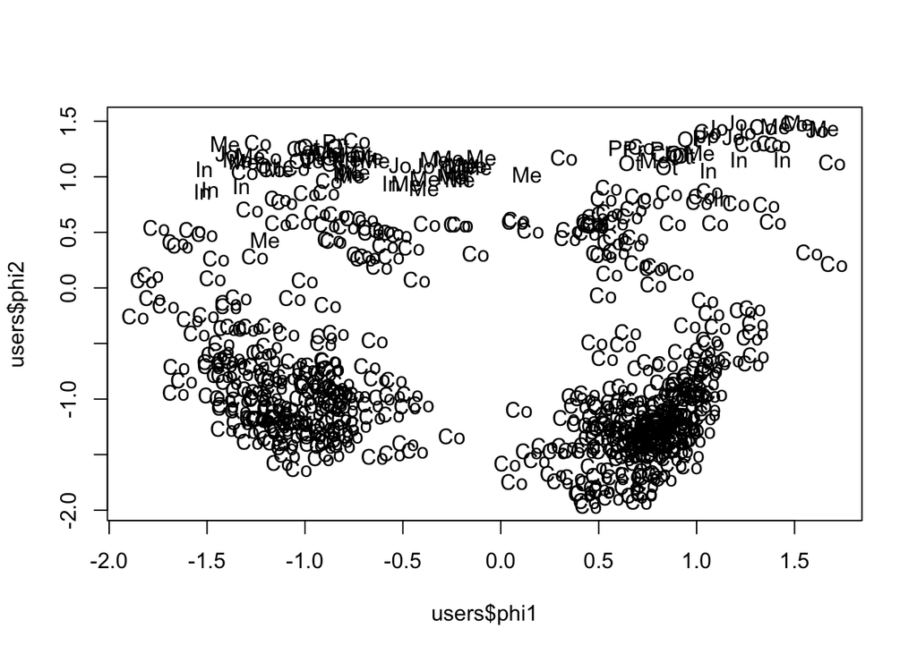

```r
# what could the second dimension mean?
plot(users$phi1, users$phi2, type="n")
text(users$phi1, users$phi2, label=substr(users$type, 1, 2))
```

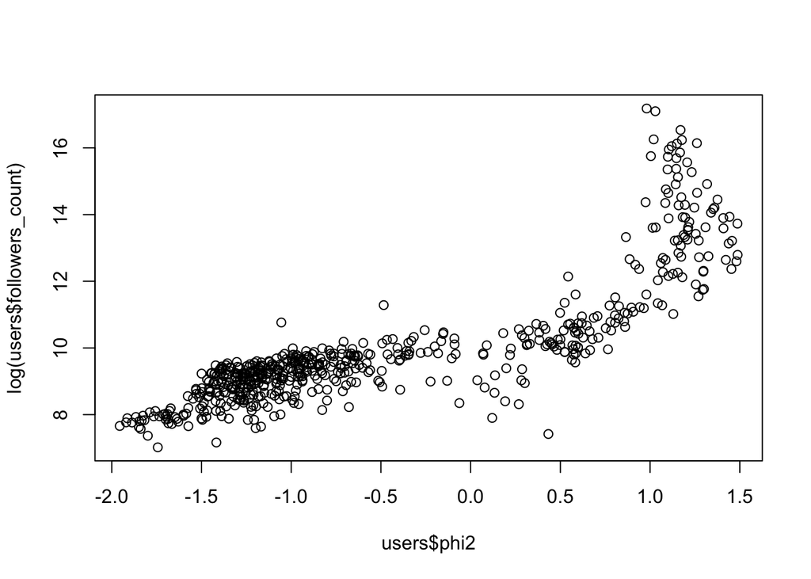

```r
plot(users$phi2, log(users$followers_count))
```

```r
cor(users$phi2, log(users$followers_count))
```

```
## [1] 0.8376895
```

```r
# primary candidates
users <- users[order(users$phi1),]
users[users$type=="Primary Candidate",c("screen_name", "phi1")]
```

```
##         screen_name       phi1
## 12    BernieSanders -0.8561287
## 78   HillaryClinton -0.7049112
## 158 realDonaldTrump  0.6037760
## 90          JebBush  0.6795725
## 115      marcorubio  0.8182496
## 558         tedcruz  1.0337009
```

```r
# others
users[users$type=="Media Outlets",c("screen_name", "phi1")]
```

```
##        screen_name        phi1
## 58          edshow -1.40767853
## 47        dailykos -1.34378181
## 563  thinkprogress -1.31280856
## 130    MotherJones -1.27878357
## 140        nprnews -1.20470194
## 4             ajam -1.13261980
## 561   TheDailyShow -0.88431403
## 131          MSNBC -0.80740165
## 548          Slate -0.78792817
## 82     HuffPostPol -0.77905989
## 134       NewsHour -0.76835924
## 75      GuardianUS -0.74307070
## 551  StephenAtHome -0.67514666
## 136      NewYorker -0.64087922
```

[output cut: 19 more lines]

```r
users[users$type=="Journalists",c("screen_name", "phi1")]
```

```
##         screen_name       phi1
## 126    MHarrisPerry -1.3994000
## 114          maddow -0.9590568
## 7    andersoncooper -0.5138587
## 74  GStephanopoulos -0.3928671
## 125      megynkelly  1.0584244
## 145   oreillyfactor  1.1035641
## 473     seanhannity  1.1878288
## 8        AnnCoulter  1.2000942
## 67        glennbeck  1.2471467
## 109        limbaugh  1.6168909
```

```r
users[users$type=="Other Politicians",c("screen_name", "phi1")]
```

```
##        screen_name       phi1
## 51            dccc -1.1964137
## 5           algore -1.0248791
## 562   TheDemocrats -0.9812492
## 98        JoeBiden -0.9721160
## 79  HouseDemocrats -0.8577119
## 153          POTUS -0.8576321
## 476     SenateDems -0.8308369
## 14     billclinton -0.7131847
## 63    GeorgeHWBush  0.6587120
## 80        HouseGOP  0.8463433
## 68             GOP  0.9011265
## 104       KarlRove  0.9136743
## 135   newtgingrich  0.9350012
## 472  SarahPalinUSA  0.9577739
```

The reason why we started with Members of Congress is that we do have good measures of ideology for these accounts – let’s now examine the convergent validity of our results by exploring how correlated our estimates are with these external measures of ideology.

```r
house <- read.csv("../data/house.csv", stringsAsFactors=F); house$chamber <- "House"
senate <- read.csv("../data/senate.csv", stringsAsFactors=F); senate$chamber <- "Senate"
ideal <- rbind(house[,c("nameid", "idealPoint", "chamber")],
            senate[,c("nameid", "idealPoint", "chamber")])
names(ideal) <- c("bioid", "ideal", "chamber")
users <- merge(users, ideal)

# validation
library(dplyr)
dd <- group_by(users, chamber, party)
summarize(dd, cor(ideal, phi1))
```

```
## # A tibble: 5 x 3
## # Groups:   chamber [?]
##   chamber       party `cor(ideal, phi1)`
##     <chr>      <fctr>              <dbl>
## 1   House    Democrat          0.6039404
## 2   House  Republican          0.4975957
## 3  Senate    Democrat          0.6736305
## 4  Senate Independent                 NA
## 5  Senate  Republican          0.5784615
```

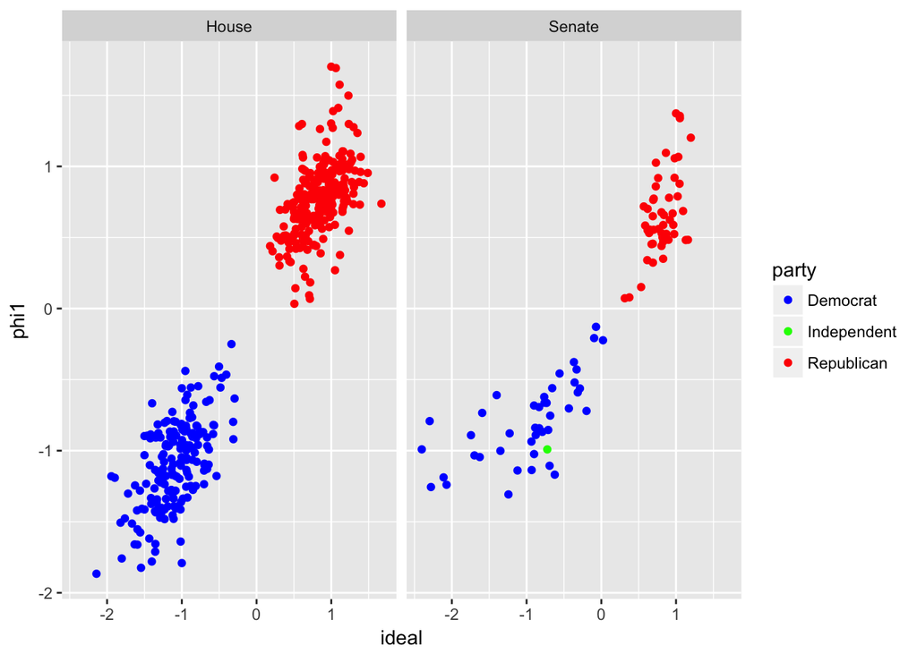

```r
library(ggplot2)
p <- ggplot(users, aes(x=ideal, y=phi1, color=party))
pq <- p + geom_point() + facet_wrap(~ chamber) +
    scale_color_manual(values=c("blue", "green", "red"))
pq
```

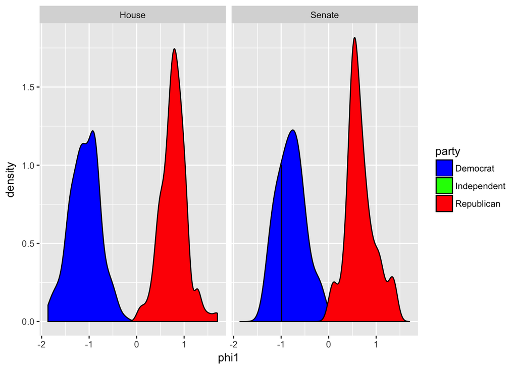

```r
p <- ggplot(users, aes(x=phi1, fill=party))
pq <- p + geom_density() + facet_wrap(~ chamber) +
    scale_fill_manual(values=c("blue", "green", "red"))
pq
```